# Inhibit Switch Tolerance Stack

Joe Shields

2017-12-08

So, I took some measurements with calipers, just listening for when the switch clicked (shown below.)

```r
meas <- read.csv('../COTS/ZFswitches/switchStats.csv')

sdMargin <- 8
peapodSlop <- 1.1
flight.free <- mean(meas$t) + sdMargin*sd(meas$t)
flight.flushSlop <- mean(meas$t) - sdMargin*sd(meas$t)
flight.flush <- flight.flushSlop-1.1

flight.free <-  round(flight.free, 1)
flight.flushSlop <-  round(flight.flushSlop, 1)
flight.flush <- round(flight.flush, 1)
```

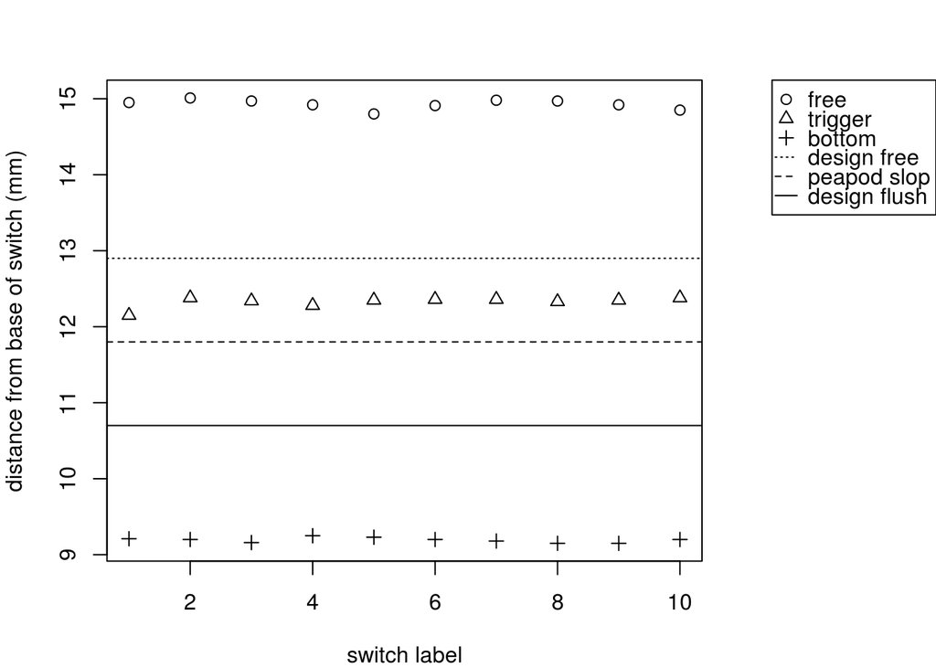

It seems like the spread between the relevant positions is large enough compared to the standard deviation that we don’t really need to worry about the statistics of switch production. I set this to give us a comfy $8\sigma$ margin around the switch trigger.

- Set the geometry such that the end of the arm is 12.9 mm away from the base of the switch when free of the peapod.
- Set the geometry such that the end of the arm is 11.8 mm away from the base of the switch when inside the peapod and pushed away from the wall.
- Set the geometry such that the end of the arm is 10.7 mm away from the base of the switch when inside the peapod and pushed against the wall.

If you need to shrink that interval, try to keep it centered around 12.33.